# Stat 218: Applied Statistics for Life Sciences

Cal Poly - San Luis Obispo, Fall 2025

## Communication

**Dr. Emily Robinson**

Email: erobin17@calpoly.edu

Office: Building 25 Office 103 (by Statistics Department Office)

**Canvas Discussion Board:**

For questions of general interest, such as course clarifications or conceptual questions, please use the Canvas Discussion page. I encourage you to give your post a concise and informative post title/first sentence, so that other people can find it. For example, *“How do I determine my data type?”* is a better title than *“help with homework”*.

While your posts are not anonymous, in this case there is no such thing as a bad question!

## Course Logistics

**Class Meeting Times:** Tuesday/Thursday

- Section 05: 2:10 - 4:00pm
- Section 06: 4:10 - 6:00pm

**Room:** Engineering West 021-0205

**Office Hours** are held in my office (25-103) during the following times:

| Day | Time |
| --- | --- |
| Monday | 1:10 - 2:30pm |
| Wednesday | 1:10 - 2:30pm |
| Thursday | 1:10 - 2:00pm |

Note that office hours are not just for when you have content questions. Stop by to introduce yourself, ask questions about the broader field of statistics, or share what you are working on!

# Course Description

Stat 218 is designed to engage you in the statistical investigation process from developing a research question and data collection methods to analyzing and communicating results. This course introduces basic descriptive and inferential statistics using both traditional (normal-distribution) and simulation approaches including confidence intervals and hypothesis testing on proportions (one-sample, two-sample), means (one-sample, two-sample, paired, ANOVA), regression, and correlation. You will be exposed to numerous examples of real-world applications of statistics that are designed to help you develop a conceptual understanding of statistics.

**Prerequisites**

Entrance to STAT 218 requires at least one of the following be met:

- Grade of C- or better in MATH 115
- Grade of B or better in MATH 96
- appropriate placement on the [Math Placement Exam](https://math.calpoly.edu/mape).

You should have familiarity with computers and technology (e.g., Internet browsing, word processing, opening/saving files, converting files to PDF format, sending and receiving e-mail, etc.).

# Learning Objectives

- Calculate and interpret various descriptive statistics.
- Identify and describe data collection methods based on simple random sampling or simple experimental designs.
- Construct and interpret confidence intervals for a single mean, differences between means for independent and paired samples, a single proportion, and the difference between two proportions from independent samples.
- Conduct and interpret hypothesis tests for the difference in two independent sample means and two independent sample proportions, Chi-square goodness-of-fit, Chi-square test for independence, and ANOVA F-test for multiple means.
- Describe relationships between two quantitative variables using simple linear regression.

# Course Tools

For each topic, you will be provided a set of *course notes* containing definitions, examples, and practice problems. We will work through each set of notes during class time (both as a large class and in groups). You are expected to either print or save the notes to your device and follow along, filling out your set of notes as we go.

Supplemental reading from [Introduction to Modern Data Science](https://openintro-ims.netlify.app/) will be recommended.

Tools you will need for this course:

Calculator (needs to be able to do basic operations)

Laptop/Chromebook/iPad Device

Online tools we will use in this course:

Online Applets https://www.rossmanchance.com/applets/index2021.html

Posit Cloud for R/RStudio https://posit.cloud *($5/mo student subscription)*

# Class Schedule & Topic Outline

This schedule is tentative and subject to change.

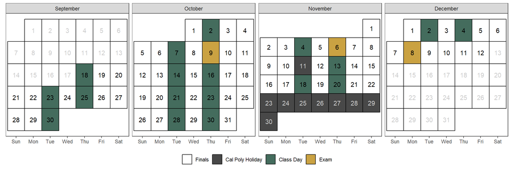

Note: I have requested a common final exam on Monday, Dec. 8th at 7:10-10pm for my two sections. This needs to be approved by the university. Please talk to me *before* you schedule travel for finals week.

Tentative schedule of class topics:

| Date | Topic |
| --- | --- |
| Sep 18 | Ch. 0 - Welcome to Stat 218 |
| Sep 23, Sep 25 | Ch. 1 - Introduction to Statistical Thinking |
| Sep 30, Oct 2 | Ch. 2 - Inference for One Proportion |
| Oct 7 | Ch. 4 - Analysis of a Single Categorical Variable |
| Oct 9 | Midterm Exam 1 |
| Oct 14, Oct 16 | Ch. 5 - Methods for Two Categorical Variables |
| Oct 21, Oct 23 | Ch. 6 - Methods for Describing a Numerical Variable |
| Oct 28, Oct 30 | Ch. 7 - Inferential Methods for a Single Numerical Variable |
| Nov 4 | Ch. 8 - Comparing a Numerical Variable Across Two Groups |
| Nov 6 | Midterm Exam 2 |
| Nov 13 | Ch. 9 - Comparing a Numerical Variable Across More than Two Groups |
| Nov 18, Nov 20 | Ch. 10 - Methods for Two Numerical Variables |
| Dec 2, Dec 4 | Final Project |
| Dec 8 | Common Final Exam |

# Course Policies

## Assessment/Grading

Your grade in STAT 218 will contain the following components:

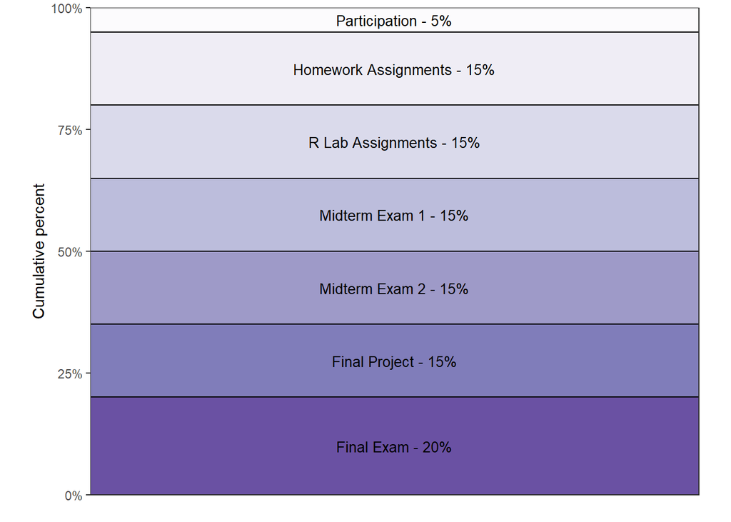

Lower bounds for grade cutoffs are shown in the following table. I will not “round up” grades at the end of the quarter. See this [thread](https://twitter.com/drseanmullen/status/1604212304622518272?s=46&t=II3oNLTSSrljVPqptoe21g) for advice on *“Playing the lines. Don’t be there.”*

| Letter grade | X + | X | X - |
| --- | --- | --- | --- |
| A | . | 93 | 90 |
| B | 87 | 83 | 80 |
| C | 77 | 73 | 70 |
| D | 67 | 63 | 60 |
| F | <60 |  |  |

Interpretation of this table:

- A grade of 85 will receive a B.
- A grade of 77 will receive a C+.
- A grade of 70 will receive a C-.
- Anything below a 60 will receive an F.

### General Evaluation Criteria

In every assignment, discussion, and written component of this class, you are expected to demonstrate that you are intellectually engaging with the material. I will evaluate you based on this engagement, which means that technically correct but low effort answers which do not demonstrate engagement or understanding will receive no credit.

While this is not an English class, grammar and spelling are important, as is your ability to communicate technical information in writing; both of these criteria will be used in addition to assignment-specific rubrics to evaluate your work.

## Assignment Breakdown

### Participation

Most of class time will be devoted to group and individual activities. Coming to class prepared to participate in these activities is vital for your success in the course. It will be left up to the discretion of the instructor whether an activity is given and graded as participation. You must be in class to receive credit for any grades under participation. There may be “entry/exit tickets” given at the beginning or end of class for participation points, data collection or simulation activities during class, or in-class discussion through online tools. You can expect at least one (maybe two) participation checks per week.

- **3** participation grades will be dropped; think of these as “sick days”.

**Note**

If you are feeling ill, please *do not come to class*. You do not need to notify me, but instead do your best to fill out the course notes found on Canvas. Then check with a group member for their notes. Work on the weekly homework/lab assignment. Stop by office hours after you are feeling better if you have any questions.

### Homework Assignments

Homework will be assigned weekly throughout the semester to provide you additional practice with the course content. Each homework assignment will be accompanied by a “homework quiz” taken on Canvas and graded for correctness; you may take the “homework quiz” twice and Canvas will keep the average of the two attempts. You will also turn in your completed homework assignment (pdf or word document) via Canvas to be checked for intellectual engagement.

- Homework Assignments are due **Thursdays at 11:59pm**.

### R Lab Assignments

Every Thursday, you will meet with your classmates and instructor to work through that week’s Posit Cloud group lab. The lab will reinforce the ideas learned in the course notes and homework assignment, through the use of R to explore and analyze data.

- Each group will turn in the lab (pdf or html file) to Canvas.
- R Labs are due as a group on **Mondays at 11:59pm**.

**Warning**

If you are absent for completing the lab with your group, you must complete the lab individually or reach an agreed upon time to meet with your group to complete the lab together.

You should *not* just add a group member’s name to the weekly lab if absent.

### Exams

Exams are closed book and notes. You are expected to take exams at the scheduled times. If this is impossible due to extreme circumstances (illness, death in the family, previously scheduled activities vital to academic program), please **notify me prior** to the examination.

You will not be required to use R/Posit Cloud for the exams, but you may be asked to fill in blanks, provided output for interpretation, or asked to select the appropriate code to complete a task.

### Final Project

There will be one project during the quarter, where you will be asked to apply the statistical concepts you have learned in the context of real data. More details will be provided during class.

## Late Policy

We are living through a challenging time with unique, unusual circumstances. I do not want class deadlines to cause you extreme stress or anxiety. I offer **3 “grace days”** – 24 hours to turn in the assignment late without a penalty. These can be used on the homework assignments and lab assignments (a single group member must be willing to use one of their grace days for the entire group), but not participation or exams. These “grace days” can be used all at once on a single assignment or used on separate assignments throughout the quarter. Simply send me an email to let me know you how many “grace days” you want to use on the assignment.

After using up your “grace days”, late work will be accepted with a 20% grade penalty for each day late (including weekends).

**Automatic Canvas Settings**

Canvas is set up to automatically input 0% for missing assignments (as an incentive to go complete the assignment) and apply the 20% grade deduction policy. I will need to manually adjust your grade when you use your grace days so it is important for you to leave a note on your assignment and email me. You are responsible for double checking your grade.

If you find yourself with extenuating circumstances beyond the defined late policy, please email me before the due date.

# Course Expectations

You will get out of this course what you put in. The following excerpt was taken from Rob Jenkins’ article “Defining the Relationship” which was published in The Chronicle of Higher Education (August 8, 2016). This accurately summarizes what I expect of you in my classroom (and also what you should expect of me).

*“I’d like to be your partner. More than anything, I’d like for us to form a mutually beneficial alliance in this endeavor we call education.*

*I pledge to do my part. I will:*

- *Stay abreast of the latest ideas in my field.*
- *Teach you what I believe you need to know; with all the enthusiasm I possess.*
- *Invite your comments and questions and respond constructively.*
- *Make myself available to you outside of class (within reason).*
- *Evaluate your work carefully and return it promptly with feedback.*
- *Be as fair, respectful, and understanding as I can humanly be.*
- *If you need help beyond the scope of this course, I will do my best to provide it or see that you get it.*

*In return, I expect you to:*

- *Show up for class each day or let me know (preferably in advance) if you have some good reason to be absent.*
- *Do your reading and other assignments outside of class and be prepared for each class meeting.*
- *Focus during class on the work we’re doing and not on extraneous matters (like whoever or whatever is on your phone at the moment).*
- *Participate in class discussions.*
- *Be respectful of your fellow students and their points of view.*
- *In short, I expect you to devote as much effort to learning as I devote to teaching.*

*What you get out of this relationship is that you’ll be better equipped to succeed in this and other college courses, work-related assignments, and life in general. What I get is a great deal of professional and personal satisfaction. Because I do really like you [all] and want the best for you.”*

# Learning Environment and Support

I am committed to creating a safe and inclusive learning environment where all students feel respected and supported. If there are any ways I can improve the classroom environment to make it more welcoming for you, please don’t hesitate to let me know.

If you have a disability and require accommodations to fully participate in the course, please contact me as soon as possible to discuss how I can best support you. I also encourage you to register with Cal Poly’s Disability Resource Center (Building 124, Room 119 or at 805-756-1395) to explore additional accommodations that may be available to you.

If you are experiencing food insecurity, housing instability, or other challenges that may impact your ability to succeed in this course, please refer to the resources listed on Canvas under “Student Support Services at Cal Poly.” These resources provide a range of essential support services, including emergency financial assistance, counseling, and academic support.

I am committed to working with you to ensure that you have the resources and support you need to succeed in this course. Let’s work together to create a positive and inclusive learning environment for all students.

# Academic Integrity and Class Conduct

Academic integrity is a fundamental value of this course and of the university. Simply put, I will not tolerate cheating, plagiarism, or any other form of academic dishonesty.

Any incident of academic misconduct, including dishonesty, copying, or plagiarism, will be reported to the Office of Student Rights and Responsibilities.

Cheating will earn you a grade of 0 on the assignment and an overall grade penalty of at least 10%. In circumstances of flagrant cheating, you may be given a grade of F in the course.

It is important to note that paraphrasing or quoting another’s work without proper citation is a form of academic misconduct.

To ensure academic integrity, please be sure to cite all sources appropriately and only use Chat GPT in an ethical manner. For more information on academic misconduct and what constitutes cheating and plagiarism, please see academicprograms.calpoly.edu/content/academicpolicies/Cheating.

# ChatGPT

Use AI as a glorified tutor, not a ghostwriter. In this course, the value of AI tools is in helping you learn, practice, and clarify. They are not meant to produce work for you. Interpretation and critical thinking are important and simply copying AI output will not meet expectations and may constitute academic misconduct.

**What’s encouraged:**

- Concept help & explanations: Ask AI to re-explain ideas in plain language, give alternative examples, or break down statistical terms.
- R support in labs: Use AI to clarify error messages, suggest functions, or outline strategies. Always run, test, and annotate the code yourself.
- Feedback on your work: Ask AI to critique your draft code or writing for clarity, not to create answers for you.

**What’s not allowed:**

- No AI-written answers submitted as your own. Interpretation is your responsibility.
- No copying/pasting code or text without understanding. Code can fail silently or even introduce harmful commands. You should always understand and adapt before running anything.
- No exam or quiz use. In-person exams are closed note/book, and AI is prohibited.
- No uncredited use. Any substantive AI assistance must be disclosed (see below).

**CSU System Policy**

Cal Poly and all CSU campuses have access to ChatGPT Edu, provided through the CSU system. This version:

- Provides advanced AI capabilities tailored for CSU students and employees.
- Includes privacy, security, and data protections (similar to email, Google Workspace, and Microsoft 365).
- Offers single sign-on (SSO) and campus workspaces for sharing.
- Protects confidentiality, though CSU has legal/operational obligations that may require access to user data. These activities are not intended to monitor legitimate academic use.

For details, see:

- [CSU Safe and Responsible Use Guidelines](https://genai.calstate.edu/guidelines-safe-and-responsible-use-generative-ai-tools)
- [CSU Student Community Resources](https://genai.calstate.edu/communities/students)

**Your responsibilities:**

- Think critically. If you can’t explain a result in your own words, you don’t understand it.
- Demonstrate engagement. Work that is technically correct but shows no reasoning or interpretation will not receive full credit.
- Acknowledge extensive AI use. At the end of any assignment where you used AI, include a brief disclosure. Example:

> AI assistance: Consulted ChatGPT for debugging ggplot2 facet labels and clarifying the difference between pooled and unpooled SD.

**Reminder:** In-person exams exist for a reason. This class emphasizes your interpretation and communication of statistical ideas.